# Harvest illustrations from periodicals

This notebook shows you how to harvest illustrations from Trove's digitised periodicals. It makes use of layout information generated by Trove's OCR processing to find the coordinates of illustrations on a digitised page. Using these coordinates the illustrations can be cropped from the page image and saved.

You can save illustrations from:

- a single page
- a complete issue
- a single article
- a search for periodical articles in the Magazines & Newsletters category

If you save illustrations from an article or a search for articles you'll probably find you get extra images that weren't in the article(s) you specified. This is because periodicals aren't segmented in the way that newspaper articles are. When you request an article, Trove basically just get redirects you to the first page on which that article appears. There's no way of knowing the boundaries of the article, so the code below just gets every image on every page on which the article appears.

## OCR data

You can access OCR data for a page using the page's `nla.obj` identifier. So if the page identifier is `nla.obj-5253237`, you request the OCR data with the url:

https://nla.gov.au/nla.obj-5253237/ocr

The structure seems to vary a bit but, in general, illustrations turn up in objects under a `zs` key, while text is under `ps`. For illustrations, the `t` key gives the type of illustration, while `b` provides the coordinates (left, top, right, bottom) in a comma-separated string.

## Illustration types

The illustration type names don't exactly match the illustration facets used in the web interface:

| Web interface | OCR data |
| --- | --- |
| Illustrated | Illustration |
| Photo | Content_Photo |
| Map | Content_Map |
| Graph | Content_Graph |
| Cartoon | Content_Cartoon |
| Music | Content_Music |

The OCR data also identifies advertisements. In the web interface, these are found by setting the `category` facet to `Advertising`. In the OCR data you need to look for the type `Advertisement`. Advertisements are, of course, a combination of text and images. Sometimes the OCR coordinates enclose both the text and the images, other times there are separate sets of coordinates for the text and images. If they're separated, you'll get multiple images for a single advertisement, and there's no easy way of knowing which illustration is associated with which block of text.

## Page resolution

One of the tricky things I discovered is that the coordinates provided by the OCR data refer to a higher-resolution version of the page image than the one accessible through the web interface. To work around this you can find the dimensions of the high-res version in the metadata embedded in the digital viewer. You can then work out the ratio of sizes and apply these to the coordinates.

## Captions

The captions of illustrations are not identified in the OCR data, they're generally just treated as text. If you want to try and include captions, you can try adding some extra space to the bottom of the illustration coordinates. To try and avoid inserting arbitrary dimensions, the code below looks at all the text on the page and finds an average line height. It then uses this value to add extra 'lines' at the bottom of the illustration. Of course, the text below an illustration might not relate to the illustration at all – there's really no way to be sure.

## What's missing?

I'm not sure how reliable the OCR data is when it comes to identifying illustrations. I've noticed some cases where the illustration details are missing. There's probably also some variation in the application of illustration types – some graphs might be labelled `Illustration`, or some maps labelled `Graph`. I think you should assume that you're not going to get *every* illustration. Nonetheless, it's a handy way of building a collection of illustrations without the overheads of machine learning.

## File names and links

The code below saves illustrations using the `nla.obj` identifier of the page on which they're published and an index number starting at 0. So the first illustration on the page with identifier `nla.obj-6840078` will be saved as `nla.obj-6840078-0.jpg`.

To view an illustration in context, simply add `https://nla.gov.au/` to the page identifier, for example: https://nla.gov.au/nla.obj-6840078. This will display the page in Trove's digitised periodical viewer.

## Import what we need

```python
import itertools
import json
import os
import re
import statistics
import time
from datetime import timedelta
from io import BytesIO
from pathlib import Path
from statistics import StatisticsError

import requests
import requests_cache
from dotenv import load_dotenv
from IPython.display import Image as Display_Image
from IPython.display import display
from PIL import Image
from requests.adapters import HTTPAdapter
from requests.packages.urllib3.util.retry import Retry
from slugify import slugify
from tqdm.auto import tqdm

s = requests_cache.CachedSession(expire_after=timedelta(days=30))
retries = Retry(total=5, backoff_factor=1, status_forcelist=[502, 503, 504])
s.mount("https://", HTTPAdapter(max_retries=retries))
s.mount("http://", HTTPAdapter(max_retries=retries))

load_dotenv()
```

```
True
```

If you're going to be saving illustrations from a search, you'll need to insert your Trove API key below.

```python
# Insert your Trove API key
API_KEY = "YOUR API KEY"

# Use api key value from environment variables if it is available
if os.getenv("TROVE_API_KEY"):
    API_KEY = os.getenv("TROVE_API_KEY")
```

## Define some functions

```python
ILL_TYPES = {
    "Illustrated": ["Illustration"],
    "Photo": ["Content_Photo", "Photo"],
    "Map": ["Content_Map", "Map"],
    "Graph": ["Content_Graph", "Graph"],
    "Cartoon": ["Content_Cartoon", "Cartoon"],
    "Music": ["Content_Music", "Music"],
}

ILL_TYPE_DEFAULTS = list(itertools.chain(ILL_TYPES.values()))


def get_metadata(id):
    """
    Extract work data in a JSON string from the work's HTML page.
    """
    if not id.startswith("http"):
        id = "https://nla.gov.au/" + id
    response = s.get(id)
    try:
        work_data = re.search(
            r"var work = JSON\.parse\(JSON\.stringify\((\{.*\})", response.text
        ).group(1)
    except AttributeError:
        work_data = "{}"
    if not response.from_cache:
        time.sleep(0.2)
    return json.loads(work_data)


def get_ill_coords(data, ill_types=ILL_TYPE_DEFAULTS):
    """
    Extract coordinates of all illustrations of the specified types from OCR data.
    """
    ill_coords = []
    # Structure of the OCR JSON varies,sometimes the top level is an object,
    # sometimes an array.
    # Try to get the `zs` block
    try:
        ill_blocks = data["print"].get("zs", [])
    # There's no `zs` key so this is probably an array
    except AttributeError:
        ill_blocks = []
        # Loop through all the blocks, keeping the `zs` labelled ones
        for section in data["print"]:
            for label, blocks in section.items():
                if label == "zs":
                    ill_blocks += blocks
    # Loop through all the saved blocks
    for block in ill_blocks:
        # Check if the illustration type is in the desired list
        if block.get("t") in ill_types:
            # Get the coordinates
            left, top, right, bottom = block["b"].split(",")
            # Add to the lisst of coords, converting strings to ints
            ill_coords.append([int(left), int(top), int(right), int(bottom)])
    return ill_coords


def get_page_size(page_id):
    """
    Get the dimensions of the current page image from embedded metadata.
    """
    metadata = get_metadata(page_id)
    for page in metadata["children"]["page"]:
        if page["pid"] == page_id:
            break
    return page["copies"][0]["technicalmetadata"]


def get_caption(data, coords, lines=5):
    """
    Adds extra space at the bottom of an image to try and include the caption.
    """
    left, top, right, bottom = coords
    heights = []
    # Get all the blocks containing text
    try:
        text_blocks = data["print"].get("ps", [])
    except AttributeError:
        text_blocks = []
        for section in data["print"]:
            for label, blocks in section.items():
                if label == "ps":
                    text_blocks += blocks
    # Loop through all text blocks and lines, saving the line heights
    for block in text_blocks:
        for line in block.get("ls", []):
            ll, lt, lr, lb = line["b"].split(",")
            heights.append(int(lb) - int(lt))

    try:
        # Return the average line height x desired number of lines
        return bottom + (statistics.median(heights) * lines)
    except StatisticsError:
        return bottom


def save_illustrations_from_page(
    page_id,
    page_size=None,
    output_path=None,
    ill_types=ILL_TYPE_DEFAULTS,
    caption_lines=0,
):
    """
    Save all illustrations of the specified type from the supplied page.
    """
    saved_images = []
    # Prepare output path where the images will be saved
    if not output_path:
        output_path = Path("illustrations", "pages", page_id)
        output_path.mkdir(exist_ok=True, parents=True)

    # Request the OCR data for this page
    try:
        response = s.get(f"https://nla.gov.au/{page_id}/ocr")
        data = response.json()
    except requests.exceptions.ContentDecodingError:
        print(page_id, "no ocr")
    else:
        # Extract the coordinates of illustrations from the OCR data
        ill_coords = get_ill_coords(data, ill_types)
        if ill_coords:
            # Need the page size to calculate the ratio and update coords
            if not page_size:
                page_size = get_page_size(page_id)
            # Download the page image
            response = s.get(f"https://nla.gov.au/{page_id}/image")
            img = Image.open(BytesIO(response.content))

            # Get the image dimensions
            width, height = img.size
            # Calculate the ratio of image dimensions to page dimensions
            try:
                ratio = width / page_size["width"]
            # Some pages have 0 for dimensions
            except ZeroDivisionError:
                print(page_id, "no dimensions")
                # Is this a useful fallback?
                ratio = 1

            # Loop through all coords
            for i, coords in enumerate(ill_coords):
                # Add some extra space at the bottom to try and include the caption
                coords[3] = get_caption(data, coords, caption_lines)
                # Update the coords using ration
                coords = [c * ratio for c in coords]
                # Crop image using the coords
                ill_img = img.crop(tuple(coords))
                # Save the cropped image
                file_name = f"{page_id}-{i}.jpg"
                ill_img.save(Path(output_path, file_name))
                saved_images.append(file_name)
        if not response.from_cache:
            time.sleep(0.2)
    return saved_images


def save_illustrations_from_issue(
    issue_id, ill_types=ILL_TYPE_DEFAULTS, caption_lines=0
):
    """
    Save all illustrations of the specified type from the supplied issue.
    """
    output_path = Path("illustrations", "issues", issue_id)
    output_path.mkdir(exist_ok=True, parents=True)
    metadata = get_metadata(issue_id)
    for page in metadata["children"]["page"]:
        save_illustrations_from_page(
            page["pid"],
            page["copies"][0]["technicalmetadata"],
            output_path,
            ill_types,
            caption_lines,
        )


def save_illustrations_from_article(
    article_id,
    output_path=None,
    ill_types=ILL_TYPE_DEFAULTS,
    caption_lines=0,
):
    """
    Save all illustrations of the specified type from the supplied article.
    """
    # print(article_id)
    if not output_path:
        output_path = Path("illustrations", "articles", article_id)
        output_path.mkdir(exist_ok=True, parents=True)
    # Get embedded metadata from viewer
    metadata = get_metadata(article_id)
    # Loop through all article records in metadata
    pages = []
    saved_images = []
    for article in metadata.get("children", {}).get("article", []):
        # When we find the article we want, save the list of pages it appears on
        if article["pid"] == article_id:
            pages = [p["page"] for p in article.get("existson", [])]
            break
    # Loop through pages
    for page_id in pages:
        page_size = None
        # Look for page info in metadata
        for page in metadata.get("children", {}).get("page", []):
            # When we find the page in metadata, save the page size details
            if page["pid"] == page_id:
                page_size = page["copies"][0]["technicalmetadata"]
                break
        if page_size:
            # Save illustrations from current page
            file_names = save_illustrations_from_page(
                page_id, page_size, output_path, ill_types, caption_lines
            )
            saved_images += file_names
    # if not saved_images:
    # print(article_id)


def get_total_results(params, headers):
    """
    Get the total number of results for a search.
    """
    these_params = params.copy()
    these_params["n"] = 0
    response = s.get(
        "https://api.trove.nla.gov.au/v3/result", params=these_params, headers=headers
    )
    data = response.json()
    return int(data["category"][0]["records"]["total"])


def get_fulltext_url(links):
    """
    Loop through the identifiers to find links to full text (digitised) versions
    """
    urls = []
    for link in links:
        if (
            "linktype" in link
            and link["linktype"] == "fulltext"
            and "nla.obj" in link["value"]
        ):
            urls.append(link["value"])
    return urls


def convert_ill_types(ill_types):
    """
    Convert illustrations types from web interface
    """
    converted_types = []
    for t in ill_types:
        converted_types += ILL_TYPES[t]
    return converted_types
    # return [ILL_TYPES[t] for t in ill_types]


def make_output_path(params, ill_types):
    query_values = [
        v
        for k, v in params.items()
        if k == "q"
        or (k.startswith("l-") and k not in ["l-IllustrationType", "l-category"])
    ]
    output_dir = slugify(" ".join(query_values + ill_types))
    output_path = Path("illustrations", output_dir)
    output_path.mkdir(exist_ok=True, parents=True)
    return output_path


def save_illustrations_from_search(query_params, ill_types=[], caption_lines=0):
    """
    Harvest illustrations from articles found using the supplied search parameters.
    """
    # Default params needed for API
    default_params = {
        "include": "links",
        "encoding": "json",
        "bulkHarvest": "true",
        "n": 100,
    }
    # Combine query and default params
    params = query_params | default_params
    # Add api key to request headers
    headers = {"X-API-KEY": API_KEY}

    # If illustration types are not specified look for them in facets and convert
    if not ill_types and "l-illustrationType" in params:
        ill_types = convert_ill_types([params["l-illustrationType"]])
    elif not ill_types and params.get("l-category") == "Advertising":
        ill_types = ["Advertisement"]
    # Otherwise use all illustration types
    elif not ill_types:
        ill_types = ILL_TYPE_DEFAULTS
    # Set path to save images
    output_path = make_output_path(params, ill_types)

    # Get the total number of results for progress bar
    total = get_total_results(params, headers)
    # Initial start value, will be replaced after each request
    start = "*"
    with tqdm(total=total) as pbar:
        # Continue until there's no start value
        while start:
            # Add start value to params
            params["s"] = start
            # Make search API request
            response = s.get(
                "https://api.trove.nla.gov.au/v3/result",
                params=params,
                headers=headers,
            )
            data = response.json()

            # Loop through the search results
            items = data["category"][0]["records"]["work"]
            for item in items:
                # Get all the article urls
                # If articles are grouped there can be multiple urls in a single work record
                urls = get_fulltext_url(item.get("identifier", []))
                # Loop through urls saving illustrations from each article
                for url in urls:
                    # Extract nla.obj id from url
                    article_id = url.strip("/").split("/")[-1]
                    save_illustrations_from_article(article_id, output_path, ill_types)
                pbar.update(1)

            # Try to get the next start value
            try:
                start = data["category"][0]["records"]["nextStart"]
            except KeyError:
                start = None
```

## Examples

### Save illustrations from a single periodical page

```python
save_illustrations_from_page("nla.obj-375667954")
```

### Save illustrations from a periodical issue

This example saves all the illustrations from the *Comment and cartoons* issue dated [7 December 1917](https://nla.gov.au/nla.obj-69915406/).

```python
save_illustrations_from_issue("nla.obj-69915406", caption_lines=5)
```

```python
save_illustrations_from_issue("nla.obj-2623004085", caption_lines=0)
```

### Save illustrations from a search for cat photos

This example searches for periodical articles with [`cat` or `kitten` in their title that are illustrated with photographs](https://trove.nla.gov.au/search/category/magazines?keyword=title%3Acat%20OR%20title%3Akitten%20OR%20title%3Acats%20OR%20title%3Akittens&l-illustrationType=Photo) and saves all the photos. Here's an [example of the results](https://www.dropbox.com/scl/fo/60imdoyf4ss2b6vh01q1w/h?rlkey=zuwbjaqnmr7qvkuinovdu5ot0&dl=0).

```python
query_params = {
    "q": "title:cat OR title:kitten OR title:cats OR title:kittens",
    "category": "magazine",
    "l-illustrationType": "Photo",
}
```

```python
save_illustrations_from_search(query_params)
```

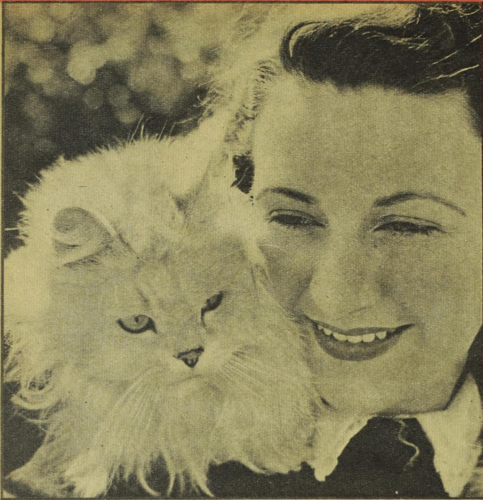

```python
img_path = make_output_path(query_params, ["Content_Photo"])
img = next(Path(img_path).glob("*.jpg"))
display(Display_Image(img, width=300))
```

### Save all the advertisements from a periodical

This is an example of harvesting illustrations from a search within a single periodical. In this case we're harvesting all the advertisements published in *The Home : an Australian quarterly*.

```python
query_params = {
    "q": "",
    "category": "magazine",
    "l-title": "The Home : an Australian quarterly",
    "l-category": "Advertising",
}

save_illustrations_from_search(query_params)
```

```python
# IGNORE TESTING ONLY
if os.getenv("GW_STATUS") == "dev":
    query_params = {
        "q": "wragge",
        "category": "magazine",
        "l-title": "Walkabout",
        "l-illustrationType": "Photo",
    }
    save_illustrations_from_search(query_params)
```

Created by [Tim Sherratt](https://timsherratt.org/) for the [GLAM Workbench](https://glam-workbench.github.io/).